# 1.the_perfect_meta

Emily Yeo

2024-09-26

http://rismyhammer.com/ml/Pre-Processing.html#imputation

# Read in meta data

used ashleys editted metadata

# Create variables

Categorize those with metabolic syndrome

# Drop and rename variables

Predictor variables will be only baseline for aim 1, and longitudinal for aim 2. That means two separate data sets.

### Aim 1 data set

Only baseline clinical variables

```r
a1_meta <- meta %>%
  dplyr::select(c(record_id, randomized_group, age, sex, race, cohort_number,
                  ethnicity, job_activity, income, marital_status,
                  height_cm, rmr_kcald_BL, spk_EE_int_kcal_day_BL,
                  WBTOT_FAT_BL, WBTOT_LEANmass_BL, wc_average_BL,
                  avg_systolic_BL, avg_diastolic_BL, C_Reactive_Protein_BL,
                  Cholesterol_lipid_BL, Triglyceride_lipid_BL,
                  HDL_Total_Direct_lipid_BL, LDL_Calculated_BL,
                  Ghrelin_BL, Leptin_BL, Peptide_YY_BL,
                  Glucose_BL, Hemoglobin_A1C_BL, Insulin_endo_BL, HOMA_IR_BL,
                  outcome_BMI_fnl_BL))

stand <- meta %>%
  dplyr::select(c(record_id,
                  subject_id,
                  randomized_group,
                  sex,
                  age,
                  Triglyceride_lipid_BL,
                  HDL_Total_Direct_lipid_BL,
                  LDL_Calculated_BL,
                  Glucose_BL, Insulin_endo_BL,
                  HOMA_IR_BL,
                  outcome_BMI_fnl_BL))

a1_meta <- stand
# Intervention : IMF = 1 , DCR = 2
head(a1_meta)
```

```
##   record_id subject_id randomized_group sex      age Triglyceride_lipid_BL
## 1         3    LFI-003                1   0 43.86138                   135
## 2         4    CBO-004                0   0 34.01849                    45
## 3         5    WPE-005                1   0 51.73823                    95
## 4         6    ROL-006                1   1 42.57457                   128
## 5         9    AKE-009                0   0 28.71254                    52
## 6        10    HGI-010                1   0 26.12785                   132
##   HDL_Total_Direct_lipid_BL LDL_Calculated_BL Glucose_BL Insulin_endo_BL
## 1                        47               106         88              10
## 2                        76                74         91               6
## 3                        56                97         84               6
## 4                        36                56         87              10
## 5                        48               111         83               7
## 6                        33                83         85              10
##   HOMA_IR_BL outcome_BMI_fnl_BL
## 1   2.151111           33.79770
## 2   1.334667           39.06705
## 3   1.232000           31.23991
## 4   2.126667           34.69726
## 5   1.420222           28.25629
## 6   2.077778           28.94347
```

# Variable distribuitons

## These tabs are kind of exploratory, so scroll

I was just looking at variable correlations, variations, summary stats and PCAs

## Looking at correlations between vars

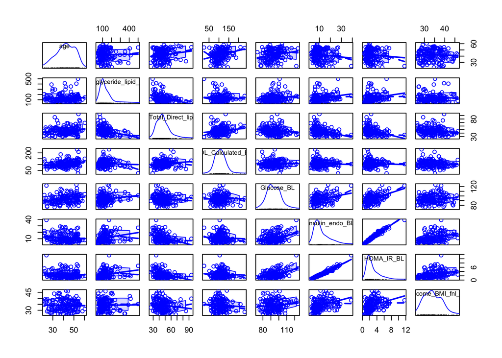

```
## 'data.frame':    159 obs. of  9 variables:
##  $ age                      : num  43.9 34 51.7 42.6 28.7 ...
##  $ sex                      : num  0 0 0 1 0 0 0 1 1 0 ...
##  $ Triglyceride_lipid_BL    : num  135 45 95 128 52 132 93 189 90 181 ...
##  $ HDL_Total_Direct_lipid_BL: num  47 76 56 36 48 33 45 31 52 58 ...
##  $ LDL_Calculated_BL        : num  106 74 97 56 111 83 132 146 112 103 ...
##  $ Glucose_BL               : num  88 91 84 87 83 85 86 103 84 86 ...
##  $ Insulin_endo_BL          : num  10 6 6 10 7 10 10 16 9 10 ...
##  $ HOMA_IR_BL               : num  2.15 1.33 1.23 2.13 1.42 ...
##  $ outcome_BMI_fnl_BL       : num  33.8 39.1 31.2 34.7 28.3 ...
```

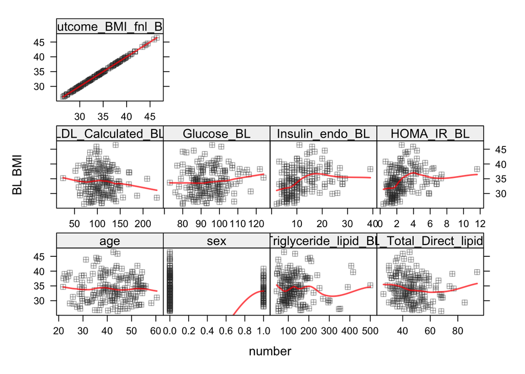

## Correlation function

```r
mosthighlycorrelated(a1_meta[5:9], 10)
```

```
##               First.Variable           Second.Variable Correlation
## 1                        age                       age           0
## 2      Triglyceride_lipid_BL                       age           0
## 3  HDL_Total_Direct_lipid_BL                       age           0
## 4          LDL_Calculated_BL                       age           0
## 5                 Glucose_BL                       age           0
## 7      Triglyceride_lipid_BL     Triglyceride_lipid_BL           0
## 8  HDL_Total_Direct_lipid_BL     Triglyceride_lipid_BL           0
## 9          LDL_Calculated_BL     Triglyceride_lipid_BL           0
## 10                Glucose_BL     Triglyceride_lipid_BL           0
## 13 HDL_Total_Direct_lipid_BL HDL_Total_Direct_lipid_BL           0
```

## Variable variations

A Profile Plot Function

Another type of plot that is useful is a profile plot, which shows the variation in each of the variables, by plotting the value of each of the variables for each of the samples.  
Function:

The arguments to the function are a vector containing the names of the varibles that you want to plot, and a list variable containing the variables themselves.

variation in standard variables

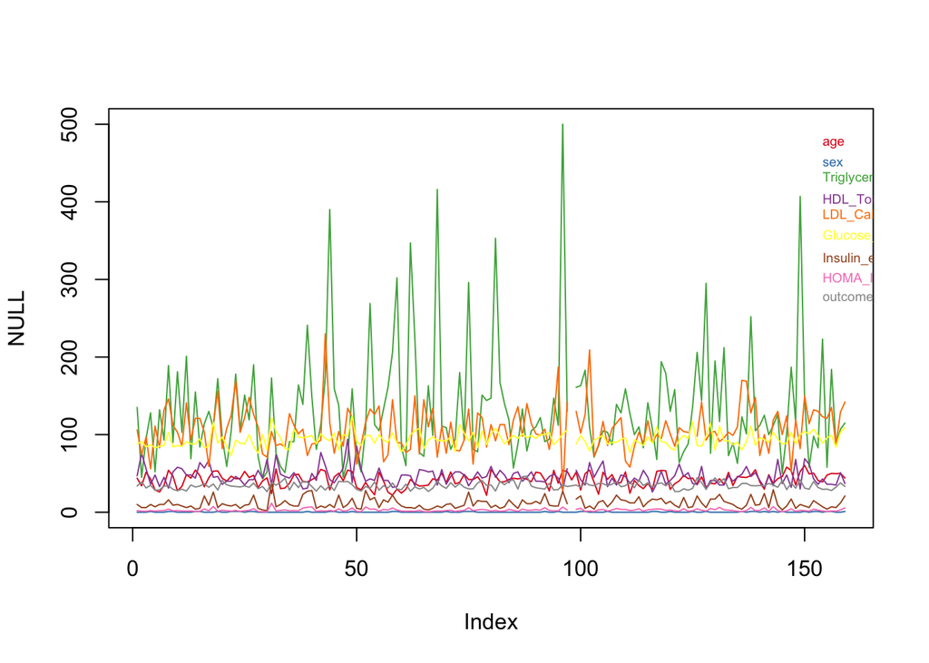

```r
makeProfilePlot(stand_list, stand)
```

I probably need to scale all my variables before this’ll make any sense

## Mean and Std. Dev.

Function by group

```r
printMeanAndSdByGroup(a1_meta[5:10],a1_meta[3])
```

```
## [1] "Means:"
##   randomized_group      age Triglyceride_lipid_BL HDL_Total_Direct_lipid_BL
## 1                0 42.16988              128.3462                  48.24359
## 2                1 41.70053              138.4304                  44.84810
##   LDL_Calculated_BL Glucose_BL Insulin_endo_BL
## 1          108.7564   93.64103        10.62821
## 2          106.4557   93.98734        12.45570
## [1] "Standard deviations:"
##   randomized_group      age Triglyceride_lipid_BL HDL_Total_Direct_lipid_BL
## 1                0 8.188990              79.21216                  12.04018
## 2                1 9.578943              70.78745                  10.08819
##   LDL_Calculated_BL Glucose_BL Insulin_endo_BL
## 1          28.52485   9.096845        6.075518
## 2          29.71652   9.075882        7.057997
## [1] "Sample sizes:"
##   randomized_group age Triglyceride_lipid_BL HDL_Total_Direct_lipid_BL
## 1                0  78                    78                        78
## 2                1  79                    79                        79
##   LDL_Calculated_BL Glucose_BL Insulin_endo_BL
## 1                78         78              78
## 2                79         79              79
```

## Standardizations

“If you want to compare different variables that have different units, are very different variances, it is a good idea to first standardize the variables. For a principal component analysis (PCA), the first principal component would be dominated by the variables which show the largest variances. Thus, its better to first standardize the variables so that they all have variance 1 and mean 0, and to then carry out the principal component analysis on the standardized data. This would allow us to find the principal components that provide the best low-dimensional representation of the variation in the original data, without being overly biased by those variables that show the most variance in the original data.”

You can standardize variables in R using the scale function.

```r
scaled_a1 <- a1_meta %>%
  mutate(across(5:12, scale))

head(scaled_a1)
```

```
##   record_id subject_id randomized_group sex         age Triglyceride_lipid_BL
## 1         3    LFI-003                1   0  0.21690128            0.02090478
## 2         4    CBO-004                0   0 -0.89715557           -1.18260140
## 3         5    WPE-005                1   0  1.10843341           -0.51398685
## 4         6    ROL-006                1   1  0.07125437           -0.07270125
## 5         9    AKE-009                0   0 -1.49770376           -1.08899536
## 6        10    HGI-010                1   0 -1.79025004           -0.01921209
##   HDL_Total_Direct_lipid_BL LDL_Calculated_BL Glucose_BL Insulin_endo_BL
## 1                0.04696372       -0.05501461 -0.6468961      -0.2294708
## 2                2.63958755       -1.15618344 -0.3213879      -0.8337437
## 3                0.85157112       -0.36471834 -1.0809071      -0.8337437
## 4               -0.93644531       -1.77559090 -0.7553989      -0.2294708
## 5                0.13636454        0.11704302 -1.1894099      -0.6826755
## 6               -1.20464778       -0.84647970 -0.9724044      -0.2294708
##   HOMA_IR_BL outcome_BMI_fnl_BL
## 1 -0.3155372        -0.07420451
## 2 -0.7926309         1.11820473
## 3 -0.8526248        -0.65301028
## 4 -0.3298214         0.12935990
## 5 -0.7426361        -1.32817727
## 6 -0.3583899        -1.17267343
```

## PCA

find the best low-dimensional representation of the variation in a multivariate data set.

https://little-book-of-r-for-multivariate-analysis.readthedocs.io/en/latest/src/multivariateanalysis.html#principal-component-analysis

```r
# use standardized variables for PCA
a1_meta_pca <- prcomp(complete.cases(scaled_a1[5:12]))
summary(a1_meta_pca)
```

```
## Importance of components:
##                           PC1
## Standard deviation     0.1118
## Proportion of Variance 1.0000
## Cumulative Proportion  1.0000
```

Standard deviation of PCAs

```r
a1_meta_pca$sdev
```

```
## [1] 0.1117989
```

Total variance explained by the components

```r
sum((a1_meta_pca$sdev)^2) # should be the same as number of variants
```

```
## [1] 0.012499
```

How many PCA to retain

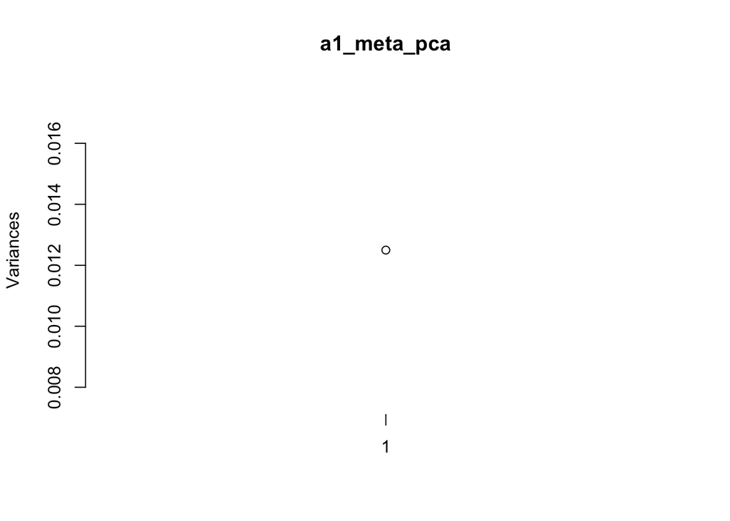

```r
screeplot(a1_meta_pca, type="lines")
```

## Zero & near zero predictors

In some situations, the data generating mechanism can create predictors that only have a single unique value (i.e. a “zero-variance predictor”). For many models (excluding tree-based models), this may cause the model to crash or the fit to be unstable.

Similarly, predictors might have only a handful of unique values that occur with very low frequencies.

```r
nzv <- nearZeroVar(a1_meta)
nzv # no zero variance predictors
```

```
## integer(0)
```

No zero variance predictors

## Linear Dependencies

The function findLinearCombos uses the QR decomposition of a matrix to enumerate sets of linear combinations (if they exist). findLinearCombos will return a list that enumerates these dependencies. For each linear combination, it will incrementally remove columns from the matrix and test to see if the dependencies have been resolved. findLinearCombos will also return a vector of column positions can be removed to eliminate the linear dependencies.

```r
#noNA_scaled_a1 <- na.omit(scaled_a1)
#comboInfo <- findLinearCombos(scaled_a1)
#comboInfo
```

# Split into training and testing

## Basic

Which is what I am currently doing. Just an 80 /20 split

```r
# Extract the continuous target variable
myTarget <- a1_meta$outcome_BMI_fnl_BL

# Remove the target column from the features
myData <- a1_meta[, !names(a1_meta) %in% "target"]

# Split the data into training and test sets
set.seed(123)  # Set seed for reproducibility

# Calculate the number of training samples (80% of total)
train_size <- floor(0.8 * nrow(myData))
inTrain <- sample(seq(nrow(myData)), size = train_size)

# Create the training and test sets
training <- myData[inTrain, ]
test <- myData[-inTrain, ]

# a1 data training and testing sets
dim(training) # 127, 10
```

```
## [1] 127  12
```

```r
dim(test) # 32, 10
```

```
## [1] 32 12
```

```r
trainTarget <- myTarget[inTrain]
testTarget <- myTarget[-inTrain]
```

## Split based on outcome

using createDataPartition - haven’t tried this

The function createDataPartition can be used to create balanced splits of the data. If the y argument to this function is a factor, the random sampling occurs within each class and should preserve the overall class distribution of the data.

The list = FALSE avoids returning the data as a list. This function also has an argument, times, that can create multiple splits at once; the data indices are returned in a list of integer vectors. Similarly, createResample can be used to make simple bootstrap samples and createFolds can be used to generate balanced crossvalidation groupings from a set of data.

```r
set.seed(3456)
trainIndex <- createDataPartition(a1_meta$outcome_BMI_fnl_BL, p = .8,
                                  list = FALSE,
                                  times = 1)
head(trainIndex)
```

```
##      Resample1
## [1,]         1
## [2,]         2
## [3,]         3
## [4,]         4
## [5,]         5
## [6,]         8
```

```r
a1_meta_Train <- a1_meta[ trainIndex,]
a1_meta_Test  <- a1_meta[-trainIndex,]
```

## Split for time series

More relevant for DF 2

# Variable transformations using Caret

Transformation & imputation using the preProcess step in the caret package. Pre-processing transformation (centering, scaling etc.) is estimated from the training data and applied to any data set with the same variables.

I played around with the settings and thresholds of this function and then looked at what it did to the distribuitions of the data.

## Impute w/ caret

```r
# Preprocess the data - imputation and scaling
preProcValues <- preProcess(training[, 5:12],
                            method = c("center",
                                       "scale",
                                       "YeoJohnson",
                                       "knnImpute",
                                       "nzv"),
          thresh = 0.95, # cutoff for cumulative % of variance to be retained by PCA
          pcaComp = NULL, #no. PCA components to keep. If specified, over-rides thresh
          na.remove = TRUE, # should missing values be removed from the calculations
          k = 5, # number of nearest neighbors from training set to use for imputation
          knnSummary = mean, # function to average neighbor values/column during imputation
          outcome = "outcome_BMI_fnl_BL",
          fudge = 0.2, # a tolerance value: Box-Cox transformation lambda values
          numUnique = 15, # no. unique values y has to estimate Box-Cox transformation
          verbose = TRUE, # a logical: prints a log as the computations proceed
          freqCut = 95/5, # cutoff for ratio of most to 2nd most common value.
          uniqueCut = 10, # cutoff % of distinct values out of no. total samples
          cutoff = 0.85, # a numeric value for the pair-wise absolute correlation cutoff.
          rangeBounds = c(0, 1)) # 2-element numeric interval for range transformation
```

```
##  applying them to training data
## Calculating 8 means for centering
## Calculating 8 standard deviations for scaling
```

```r
# Apply tranformation

# Combine the original first four columns with the transformed columns
train_to_predict <- training %>% dplyr::select(c("age", "Triglyceride_lipid_BL", "HDL_Total_Direct_lipid_BL",
                     "LDL_Calculated_BL", "Glucose_BL", "Insulin_endo_BL", "HOMA_IR_BL", "outcome_BMI_fnl_BL"))
test_to_predict <- test %>% dplyr::select(c("age", "Triglyceride_lipid_BL", "HDL_Total_Direct_lipid_BL",
                     "LDL_Calculated_BL", "Glucose_BL", "Insulin_endo_BL", "HOMA_IR_BL", "outcome_BMI_fnl_BL"))
a1_to_predict <- a1_meta %>% dplyr::select(c("age", "Triglyceride_lipid_BL", "HDL_Total_Direct_lipid_BL",
                     "LDL_Calculated_BL", "Glucose_BL", "Insulin_endo_BL", "HOMA_IR_BL", "outcome_BMI_fnl_BL"))

train_Transformed <- cbind(training[, 1:4], predict(preProcValues, train_to_predict))
test_Transformed <- cbind(test[, 1:4], predict(preProcValues, test_to_predict))
a1_meta_Transformed <- cbind(a1_meta[, 1:4], predict(preProcValues, a1_to_predict))

#train_Transformed <- predict(preProcValues, training)
#test_Transformed <- predict(preProcValues, test)
#a1_meta_Transformed <- predict(preProcValues, a1_meta)
```

## Differences w/ Caret

Lookiing at the differences in original vs. transformed data

histograms:

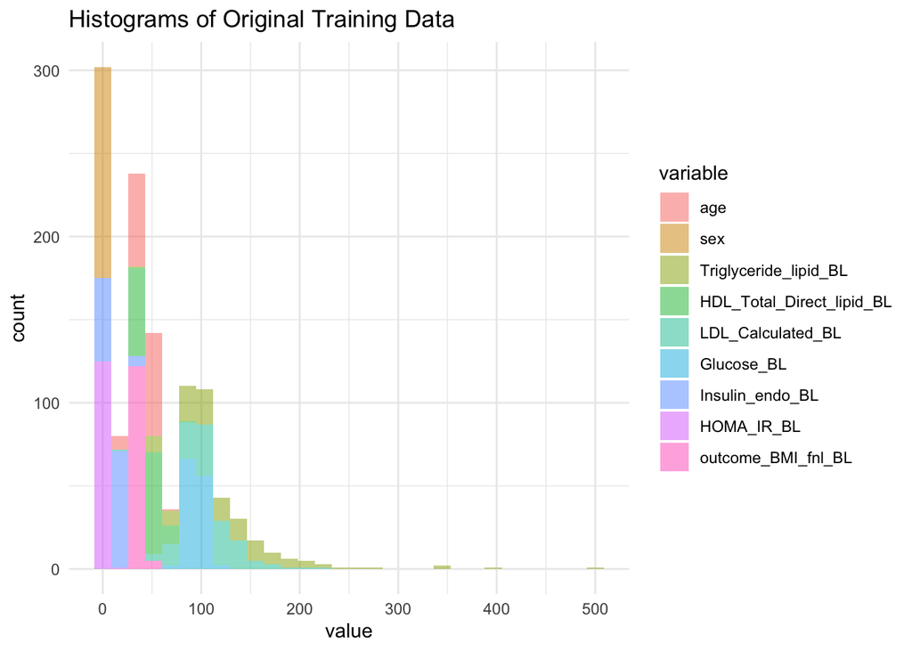

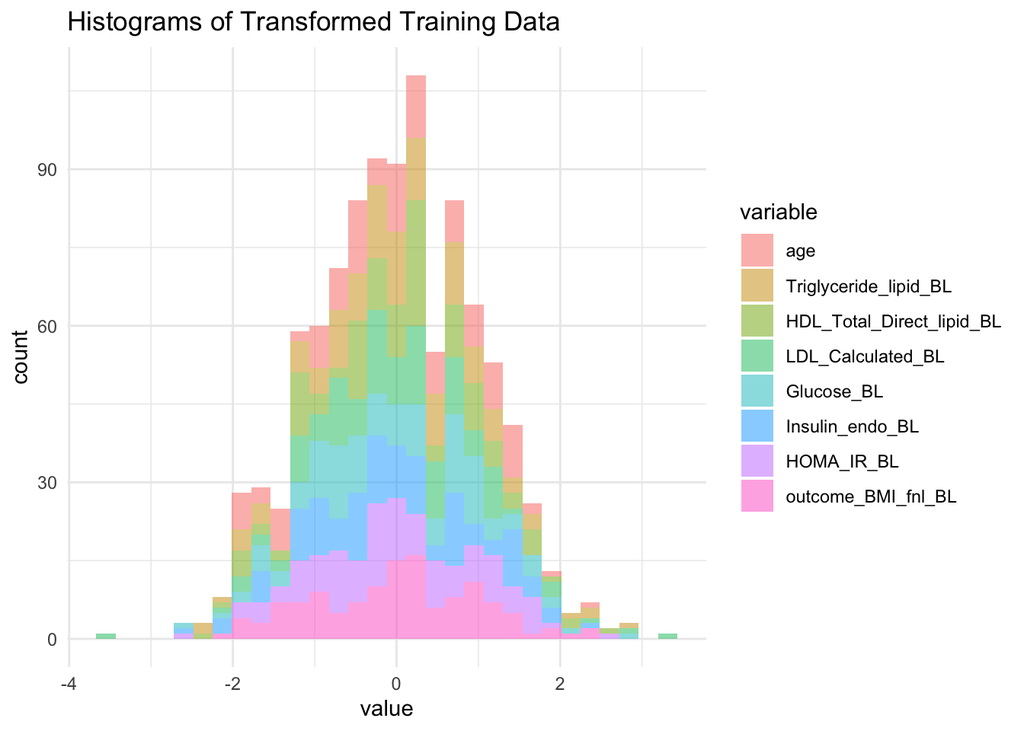

density plots

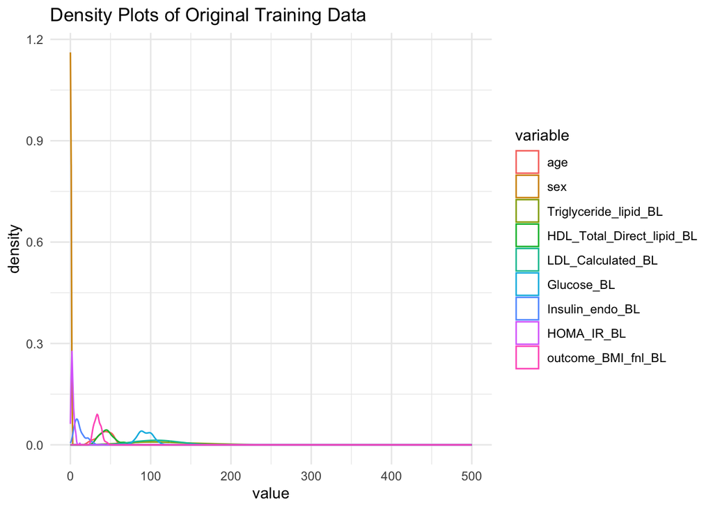

```r
# Density plots
ggplot(original_melted_training_old, aes(x = value, color = variable)) +
    geom_density() +
    ggtitle("Density Plots of Original Training Data") +
    theme_minimal()
```

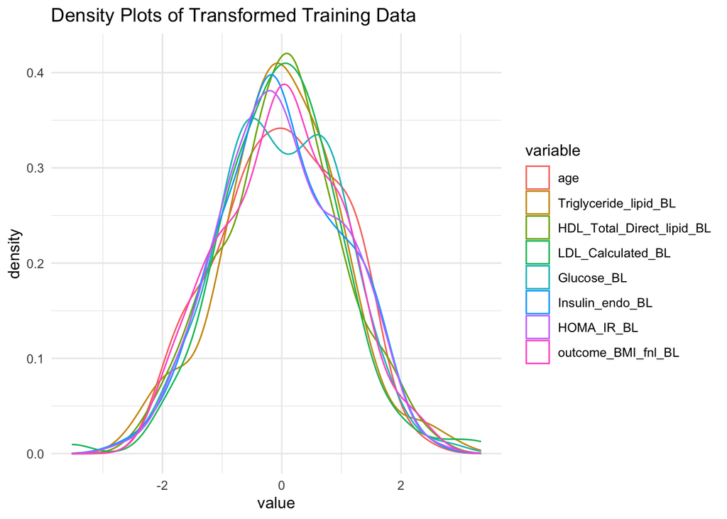

```r
ggplot(transformed_melted, aes(x = value, color = variable)) +
    geom_density() +
    ggtitle("Density Plots of Transformed Training Data") +
    theme_minimal()
```

Boxplots

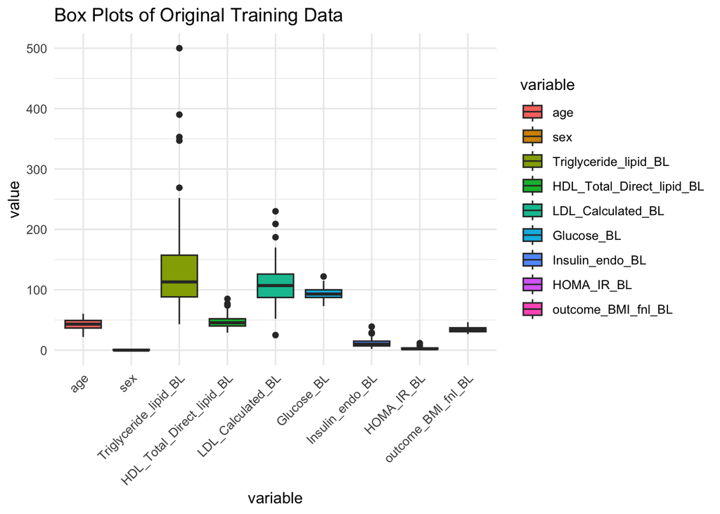

```r
# Box plots
ggplot(original_melted_training_old, aes(x = variable, y = value, fill = variable)) +
    geom_boxplot() +
    ggtitle("Box Plots of Original Training Data") +
    theme_minimal() +
    theme(axis.text.x = element_text(angle = 45, hjust = 1))
```

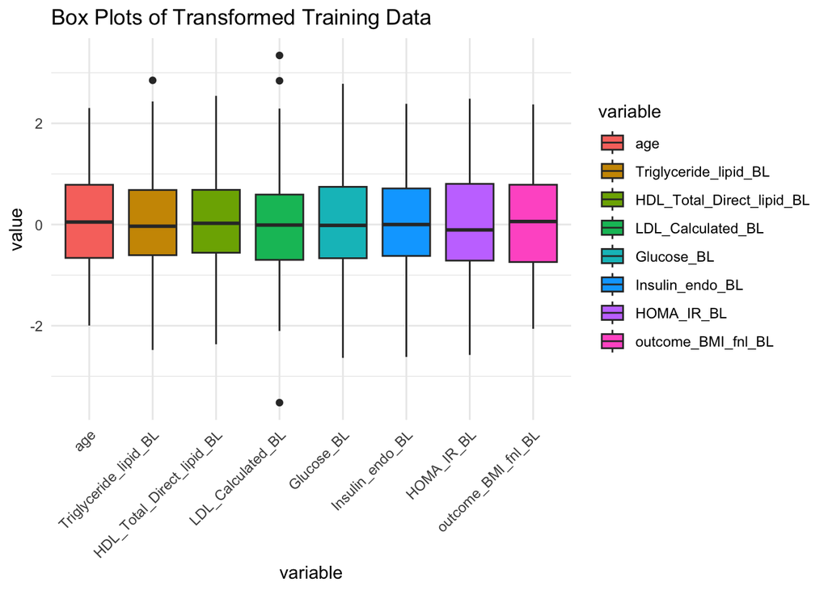

```r
ggplot(transformed_melted, aes(x = variable, y = value, fill = variable)) +
    geom_boxplot() +
    ggtitle("Box Plots of Transformed Training Data") +
    theme_minimal() +
    theme(axis.text.x = element_text(angle = 45, hjust = 1))
```

corr heatmaps

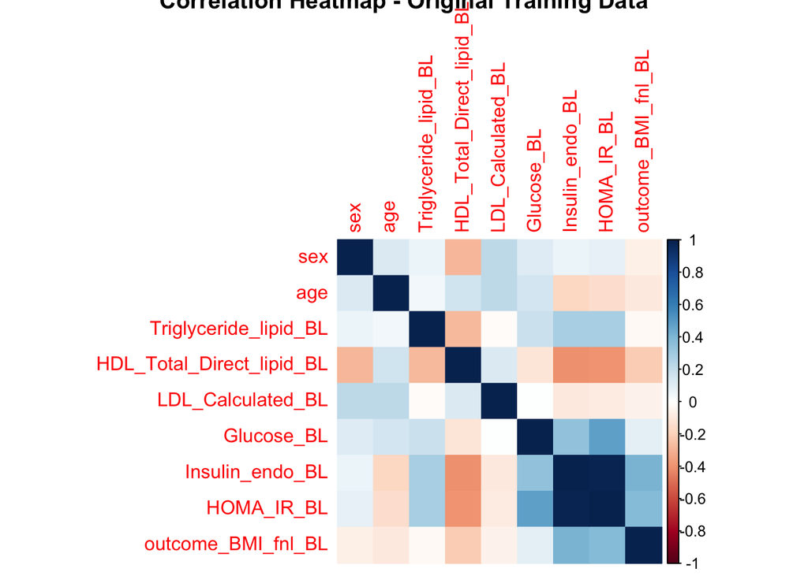

```r
# Compute correlations
original_cor <- cor(training[4:12], use = "pairwise.complete.obs")
transformed_cor <- cor(train_Transformed[4:12], use = "pairwise.complete.obs")

# Plot correlation heatmaps
corrplot(original_cor, method = "color",
         title = "Correlation Heatmap - Original Training Data",
         mar = c(0, 0, 0, 0))
```

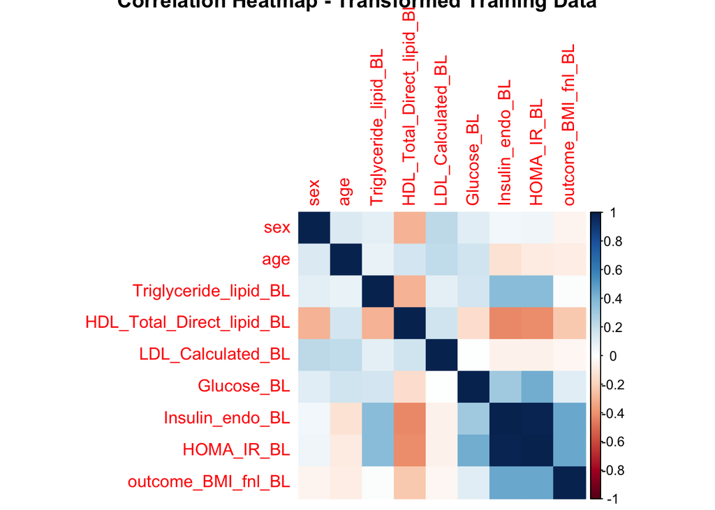

```r
corrplot(transformed_cor, method = "color",
         title = "Correlation Heatmap - Transformed Training Data",
         mar = c(0, 0, 0, 0))
```

About preProcessing function: Pre-processing transformation (centering, scaling etc.) can be estimated from the training data and applied to any data set with the same variables.

The operations are applied in this order: zero-variance filter, near-zero variance filter, correlation filter, Box-Cox/Yeo-Johnson/exponential transformation, centering, scaling, range, imputation, PCA, ICA then spatial sign.

k-nearest neighbor imputation is carried out by finding the k closest samples (Euclidian distance) in the training set. Imputation via bagging fits a bagged tree model for each predictor (as a function of all the others). This method is simple, accurate and accepts missing values, but it has much higher computational cost. Imputation via medians takes the median of each predictor in the training set, and uses them to fill missing values. This method is simple, fast, and accepts missing values, but treats each predictor independently, and may be inaccurate.

method: a character vector specifying the type of processing. Possible values are: “BoxCox” - developed for transforming the response variable. Must be positive. “YeoJohnson” - Similar to the Box-Cox model but can accommodate predictors with zero and/or negative values. “expoTrans”- The exponential transformation of Manly can also be used for positive or negative data. “center” - Subtracts the mean of the predictor’s data (again from the data in x) from the predictor values. “scale” - Divides by the standard deviation. “range” - The “range” transformation scales the data to be within rangeBounds. If new samples have values larger or smaller than those in the training set, values will be outside of this range. “knnImpute” - k-nearest neighbor imputation is carried out by finding the k closest samples (Euclidian distance) in the training set. “bagImpute” - Imputation via bagging fits a bagged tree model for each predictor (as a function of all the others). This method is simple, accurate and accepts missing values, but it has much higher computational cost. “medianImpute” - Imputation via medians takes the median of each predictor in the training set, and uses them to fill missing values. This method is simple, fast, and accepts missing values, but treats each predictor independently, and may be inaccurate. “pca” - A warning is thrown if both PCA and ICA are requested. ICA, as implemented by the fastICA package automatically does a PCA decomposition prior to finding the ICA scores. “ica”, “spatialSign”, “corr” - “corr” seeks to filter out highly correlated predictors. “zv” - identifies numeric predictor columns with a single value (i.e. having zero variance) and excludes them from further calculations.  
“nzv” - “nzv” does the same by applying nearZeroVar exclude “near zero-variance” predictors. “conditionalX” - For classification, method = “conditionalX” examines the distribution of each predictor conditional on the outcome. If there is only one unique value within any class, the predictor is excluded from further calculations (see checkConditionalX for an example). When outcome is not a factor, this calculation is not executed.

thresh: a cutoff for the cumulative percent of variance to be retained by PCA. Set to 0.95.

pcaComp: the specific number of PCA components to keep. If specified, this over-rides thresh

# Data summary of transformed

## First looking at the variatioons in the data

```r
socio_t <- c("age","race","income","job_activity","marital_status",
             "ethnicity","outcome_BMI_fnl_BL")

blood_bp_t <- c("avg_systolic_BL", "avg_diastolic_BL", "C_Reactive_Protein_BL",
              "Cholesterol_lipid_BL","Triglyceride_lipid_BL", "outcome_BMI_fnl_BL")

sugar_t  <- c("Glucose_BL", "Hemoglobin_A1C_BL", "Insulin_endo_BL",
              "HOMA_IR_BL","outcome_BMI_fnl_BL")

hunger_t  <- c("Ghrelin_BL", "Leptin_BL", "Peptide_YY_BL","outcome_BMI_fnl_BL")

body_t  <- c("height_cm", "wc_average_BL", "WBTOT_FAT_BL",
             "WBTOT_LEANmass_BL","outcome_BMI_fnl_BL")

energy_t  <- c("spk_EE_int_kcal_day_BL", "rmr_kcald_BL","outcome_BMI_fnl_BL")

socio_list_t  <- list(train_Transformed$age, train_Transformed$race,
                      train_Transformed$income, train_Transformed$job_activity,
                      train_Transformed$marital_status, train_Transformed$ethnicity,
                      train_Transformed$outcome_BMI_fnl_BL)

blood_bp_list_t  <- list(train_Transformed$avg_systolic_BL,
                         train_Transformed$avg_diastolic_BL,
                         train_Transformed$C_Reactive_Protein_BL,
                         train_Transformed$Cholesterol_lipid_BL,
                         train_Transformed$Triglyceride_lipid_BL,
                         train_Transformed$outcome_BMI_fnl_BL)

sugar_list_t  <- list(train_Transformed$Glucose_BL,
                      train_Transformed$Hemoglobin_A1C_BL,
                      train_Transformed$Insulin_endo_BL,
                      train_Transformed$HOMA_IR_BL,
                      train_Transformed$outcome_BMI_fnl_BL)

hunger_list_t  <- list(train_Transformed$Ghrelin_BL, train_Transformed$Leptin_BL,
                    train_Transformed$Peptide_YY_BL,
                    train_Transformed$outcome_BMI_fnl_BL)

body_list_t  <- list(train_Transformed$height_cm, train_Transformed$wc_average_BL,
                     train_Transformed$WBTOT_FAT_BL,
                     train_Transformed$WBTOT_LEANmass_BL,
                     train_Transformed$outcome_BMI_fnl_BL)

energy_list_t  <- list(train_Transformed$spk_EE_int_kcal_day_BL,
                       train_Transformed$rmr_kcald_BL,
                       train_Transformed$outcome_BMI_fnl_BL)

stand_t <- c("age", "sex", "Triglyceride_lipid_BL", "HDL_Total_Direct_lipid_BL",
                  "LDL_Calculated_BL", "Glucose_BL", "Insulin_endo_BL",
                  "HOMA_IR_BL", "outcome_BMI_fnl_BL")

stand_list_t <- list(train_Transformed$age,
                     train_Transformed$sex,
                     train_Transformed$Triglyceride_lipid_BL,
                     train_Transformed$HDL_Total_Direct_lipid_BL,
                     train_Transformed$LDL_Calculated_BL,
                     train_Transformed$Glucose_BL,
                      train_Transformed$Insulin_endo_BL,
                      train_Transformed$HOMA_IR_BL,
                      train_Transformed$outcome_BMI_fnl_BL)
```

Clinical standard variable transformed variation

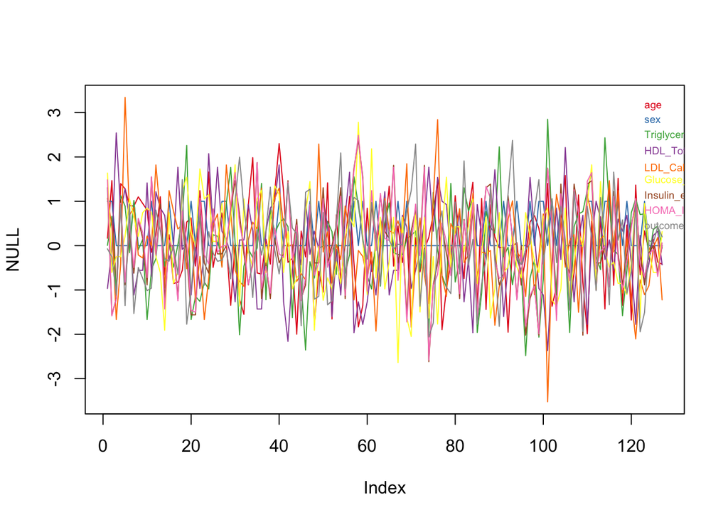

```r
makeProfilePlot(stand_list_t, stand_t)
```

## Mean and std.

```r
printMeanAndSdByGroup(train_Transformed[2:10],train_Transformed[3])
```

[output not shown]

```
## [1] "Means:"
##   randomized_group subject_id randomized_group sex age Triglyceride_lipid_BL
## 1                0         NA               NA  NA  NA                    NA
## 2                1         NA               NA  NA  NA                    NA
##   HDL_Total_Direct_lipid_BL LDL_Calculated_BL Glucose_BL Insulin_endo_BL
## 1                        NA                NA         NA              NA
## 2                        NA                NA         NA              NA
```

```
## [1] "Standard deviations:"
##   randomized_group subject_id randomized_group       sex       age
## 1                0         NA                0 0.4459485 0.9316857
## 2                1         NA                0 0.4541382 1.0628908
##   Triglyceride_lipid_BL HDL_Total_Direct_lipid_BL LDL_Calculated_BL Glucose_BL
## 1             1.0297830                  1.050448         0.9845432  1.0092617
## 2             0.9688465                  0.937377         1.0107125  0.9889371
##   Insulin_endo_BL
## 1       0.9754584
## 2       1.0175084
## [1] "Sample sizes:"
##   randomized_group subject_id randomized_group sex age Triglyceride_lipid_BL
## 1                0         60               60  60  60                    60
## 2                1         67               67  67  67                    67
##   HDL_Total_Direct_lipid_BL LDL_Calculated_BL Glucose_BL Insulin_endo_BL
## 1                        60                60         60              60
## 2                        67                67         67              67
```

## Correlation when transformed

```r
mosthighlycorrelated(train_Transformed[4:12], 8) # top most correlated variables
```

```
##               First.Variable    Second.Variable Correlation
## 70           Insulin_endo_BL         HOMA_IR_BL   0.9894153
## 79           Insulin_endo_BL outcome_BMI_fnl_BL   0.4594658
## 80                HOMA_IR_BL outcome_BMI_fnl_BL   0.4518679
## 69                Glucose_BL         HOMA_IR_BL   0.4336652
## 58 HDL_Total_Direct_lipid_BL    Insulin_endo_BL  -0.4204438
## 67 HDL_Total_Direct_lipid_BL         HOMA_IR_BL  -0.4159398
## 66     Triglyceride_lipid_BL         HOMA_IR_BL   0.3777283
## 57     Triglyceride_lipid_BL    Insulin_endo_BL   0.3770156
```

## Save meta data and splits for samples

```r
#write.csv(train_Transformed,
#        "/Users/emily/projects/research/Stanislawski/comps/mutli-omic-predictions/data/clinical/transformed/aim1/train_samples_standard_clinical.csv")

#write.csv(test_Transformed,
#        "/Users/emily/projects/research/Stanislawski/comps/mutli-omic-predictions/data/clinical/transformed/aim1/test_samples_standard_clinical.csv")

#write.csv(a1_meta_Transformed,
#        "/Users/emily/projects/research/Stanislawski/comps/mutli-omic-predictions/data/clinical/transformed/aim1/a1_meta_Transformed_standard_clinical.csv")
```

# Ignore below

## Model training with imputed data

## random forest with imputed training data

mtry is a hyperparameter that controls the number of variables (predictors) that are randomly selected for consideration at each split in the decision trees that make up the forest.

```r
# fitControl <- trainControl(## 10-fold CV
#                            method = "repeatedcv",
#                            number = 10,
#                            repeats = 10, ## k-fold repeated ten times
#                            p = 0.80,
#                            verboseIter = TRUE,
#                            summaryFunction = defaultSummary,
#                            selectionFunction = "best",
#                            savePredictions = "final")
#
# gbmFit1 <- train(outcome_BMI_fnl_BL ~ ., data = train_Transformed,
#                  method = "rf",
#                  trControl = fitControl,
#                  verbose = TRUE)
#
# gbmFit1
# plot(gbmFit1)
```

```r
# gbmFit1$bestTune
# head(gbmFit1$results)
```

```r
# trellis.par.set(caretTheme())
# plot(gbmFit1, metric = "Rsquared")
```

```r
#ggplot(gbmFit1)
```

## Variable importances

The function automatically scales the importance scores to be between 0 and 100. Using scale = FALSE avoids this normalization step.

```r
# gbmImp <- varImp(gbmFit1, scale = TRUE)
# plot(gbmImp)
```

## Feature selections

```r
# # define the control using a random forest selection function
# control <- rfeControl(functions=rfFuncs, method="cv", number=10)
# # run the RFE algorithm
# results <- rfe(train_Transformed[,2:30],
#                train_Transformed[,31], sizes=c(1:16),
#                rfeControl=control)
# # summarize the results
# print(results)
# predictors(results) # list the chosen features
# plot(results, type=c("g", "o")) # plot the results
```

## Changing tolerance

Tolerance selects the least complex model within some % tolerance of the best value. Less complex model based on (x-xbest)/xbestx 100, which is the % difference. For example, to select parameter values based on a 12% loss of performance:

```r
# whichTwoPct <- tolerance(gbmFit1$results, metric = "Rsquared",
#                          tol = 12, maximize = TRUE)
# cat("best model within 12 pct of best:\n")
# gbmFit1$results[whichTwoPct,1:6]
```

# Put it all together

so the splitting and imputing above can all be combined into the “training” step below. For the ranfom forest model, - first I’ll select the number of folds. - 2nd will be the trainControl parameters - lastly will be training

## folds

to do

## trainControl settings 1

Lots of settings here

```r
# trn_ctrl_1 <- trainControl(method = "cv", # cross val
#                          #number = "10", # 10 fold
#                          #repeats = 5, # no. complete sets of folds to compute
#                          number = ifelse(grepl("cv", "cv"), 10, 25),
#                          repeats = ifelse(grepl("[d_]cv$", "cv"), 1, NA),
#                          p = 0.80, # the training percentage
#                          search = "grid", # tuning parameter grid determination,
#                          verboseIter = TRUE, # print log
#                          returnData = TRUE, # save data
#                          #returnResamp = "all", # resampling summary metrics saved
#                          savePredictions = "all", # final would save the optimal
#                          classProbs = FALSE, # for classification models
#                          summaryFunction = defaultSummary,
#                          selectionFunction = "best", # for best tuning parameter
#                          preProcOptions = list("scaling", "centering", "knn",
#                                                thresh = 0.95,
#                                                ICAcomp = 3,
#                                                k = 5, freqCut = 95/5,
#                                                uniqueCut = 10,
#                                                cutoff = 0.9),
#                          sampling = NULL,
#                          index = NULL,
#                          indexOut = NULL,
#                          indexFinal = NULL,
#                          timingSamps = 0,
#                          predictionBounds = rep(FALSE, 2),
#                          seeds = NA,
#                          adaptive = list(min = 5,
#                                          alpha = 0.05,
#                                          method = "gls",
#                                          complete = TRUE),
#                          trim = FALSE,
#                          allowParallel = TRUE)
```

## Train Control 2

```r
# trn_ctrl_2 <- trainControl(
#   method = "cv",                  # Use cross-validation
#   number = 10,                    # Number of folds
#   p = 0.80,                       # % of data used for training (only applicable for some methods)
#   search = "grid",                # Grid search for tuning
#   verboseIter = TRUE,             # Print iteration details
#   returnData = TRUE,              # Return the data used for resampling
#   savePredictions = "all",        # Save all predictions
#   classProbs = FALSE,             # Whether to compute class probabilities (for classification)
#   summaryFunction = defaultSummary,  # Function to summarize model performance
#   selectionFunction = "best",     # Select the best tuning parameter
#   allowParallel = TRUE)            # Allow parallel processing
#
# # Define trainControl with cross-validation
# trn_ctrl_3 <- trainControl(
#   method = "cv",                  # Cross-validation
#   number = 10,                    # 10-fold cross-validation
#   savePredictions = "all",        # Save all predictions
#   classProbs = FALSE,             # Not a classification problem
#   summaryFunction = defaultSummary,
#   allowParallel = TRUE,
#   preProcOptions = list("scaling",
#                         "centering",
#                         "knn",
#                          thresh = 0.95,
#                          ICAcomp = 3,
#                          k = 5, freqCut = 95/5,
#                          uniqueCut = 10,
#                          cutoff = 0.9)) # Enable parallel processing
```

## Train RF model

```r
# indep_var = colnames(a1_meta) != "outcome_BMI_fnl_BL"
# model_rf = train(x = a1_meta[indep_var],
#                  y = a1_meta$outcome_BMI_fnl_BL,
#                  method = "rf",   # Random Forest method
#                  metric = "RMSE",                # Performance metric
#                  maximize = FALSE,               # Whether to maximize the metric
#                  trControl = trn_ctrl_2,           # Control parameters
#                  tuneGrid = NULL,                # Grid for tuning parameters
#                  tuneLength = 3,
#                  preProcess = list("scaling",
#                         "centering",
#                         "knnIm")) # Number of tuning parameters to try
#
# model <- train(x = a1_meta[indep_var],
#                y = a1_meta$outcome_BMI_fnl_BL,             # Outcome variable
#                method = "rf",                  # Random Forest method
#                metric = "RMSE",                # Performance metric
#                maximize = FALSE,               # Whether to maximize the metric
#                trControl = trn_ctrl_1,           # Control parameters
#                tuneGrid = NULL,                # Grid for tuning parameters
#                tuneLength = 3)                # Number of tuning parameters to try
#
# # Train the model
# model <- train(
#   outcome_BMI_fnl_BL ~ .,         # Formula specifying the outcome
#   data = a1_meta,                 # Dataset
#   method = "rf",                  # Random forest method
#   metric = "RMSE",                # Performance metric
#   maximize = FALSE,               # Minimize RMSE
#   trControl = trn_ctrl,
# )
```

I was confused about imputation with k-fold cross validation. Should this be done before or after or on each split. I decided to follow this tutorial: https://quantdev.ssri.psu.edu/tutorials/supervised-machine-learning-caret-package file:///Users/emily/Downloads/Supervised_Machine_Learning_The_Caret_Package.html http://topepo.github.io/caret/visualizations.html

## 1. Imputing using KNN, also centering & scaling numerical columns

I dont know if I should do this before splitting data, or within each fold ?

```r
a1_meta_pre <- preProcess(a1_meta, method = c("knnImpute","center","scale"))
a1_meta_imp <-predict(a1_meta_pre, a1_meta)
```

### Take 3

```r
# library(randomForest)
# rf_model <- randomForest(outcome_BMI_fnl_BL ~ .,
#                          data=train_Transformed, importance=TRUE)
#
# # Evaluate the model:
# predictions <- predict(rf_model, newdata=test_Transformed)
# confusion_matrix <- table(test_Transformed$outcome_BMI_fnl_BL, predictions)
# print(confusion_matrix)
#
# # Calculate accuracy
# accuracy <- sum(diag(confusion_matrix)) / sum(confusion_matrix)
# print(accuracy)
#
# # Feature importance
# importance(rf_model)
# varImpPlot(rf_model)
```